# Reproducible Research: Peer Assessment 1 (Fancy clothes)

José Antonio García Ramirez

December 11, 2016

## Loading and preprocessing the (smart) data

First we get the data directly from the [url](https://d396qusza40orc.cloudfront.net/repdata%2Fdata%2Factivity.zip), then unzip it and with the library -lubridate- and transform the variable ‘date’ to a lubridate’s date type.

```r
temp <- tempfile()
download.file('https://d396qusza40orc.cloudfront.net/repdata%2Fdata%2Factivity.zip',temp)
data <- read.csv(unz(temp, "activity.csv"), header = TRUE)
head(data)
```

```
##   steps       date interval
## 1    NA 2012-10-01        0
## 2    NA 2012-10-01        5
## 3    NA 2012-10-01       10
## 4    NA 2012-10-01       15
## 5    NA 2012-10-01       20
## 6    NA 2012-10-01       25
```

```r
unlink(temp)
library(lubridate)
data$date <- ymd(data$date)
rows <- dim(data)[1]
vars <- dim(data)[2]
```

And we check for the dimensionality of the dataset to check that it has 17568 observations and 3 variables.

## Mean total number of steps taken per day.

First we observe the distribution of the variable: number of step of the anonymous individual in each time, first group by the date (I will use the package dplyr to manipulate the data).

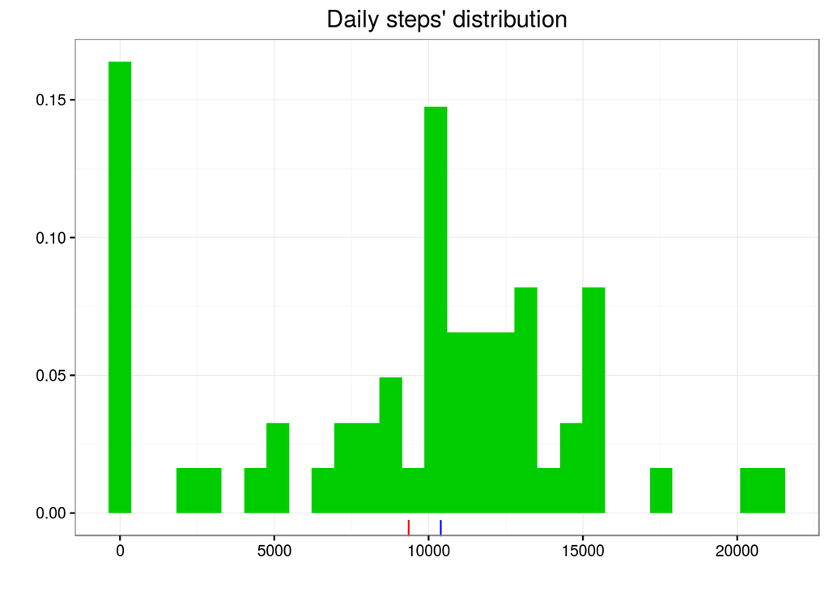

```r
library(ggplot2)
library(dplyr)
a <- data %>% group_by(date) %>% summarise(steps=sum(steps, na.rm =TRUE))
m <- mean(a$steps, na.rm = TRUE)
med <- median(a$steps, na.rm = TRUE)
rugs <- data.frame(steps=c(m,med))
ggplot(a, aes(x = steps)) + geom_histogram(aes(y = ..count../sum(..count..)), fill='green3') + ggtitle("Daily steps' distribution") + ylab('')+ xlab('') +theme_bw() +geom_rug(data = rugs, colour = c('red', 'blue'))
```

The plot has two rugs, in red color the mean number of steps (9354.2295082) and another one in blue color indicating the median (10395).

## Average daily activity pattern.

First we observe the distribution of the variable across the intervals and it is calculated it’s average number of steps

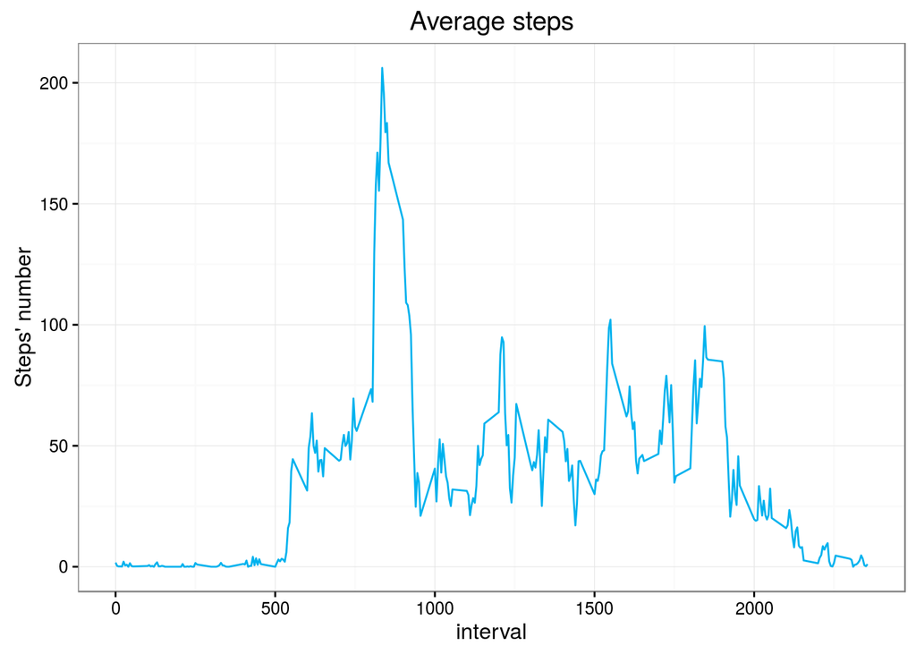

```r
a <- data %>% group_by(interval) %>% summarise(steps=mean(steps, na.rm = TRUE))
maxInterval <-a$interval[which.max(a$steps)]
ggplot(a, aes(x = interval, y = steps)) + geom_line(colour = 'deepskyblue2') +
    ylab("Steps' number") + theme_bw()  + ggtitle('Average steps')+
    theme_bw()
```

The interval with maximum average steps’ number is (835).

## Imputing missing values.

```r
nas <- sum(is.na(data$steps))
```

The number of missing values in the dataset is 2304. I will fill NA’s with the mean of the interval.

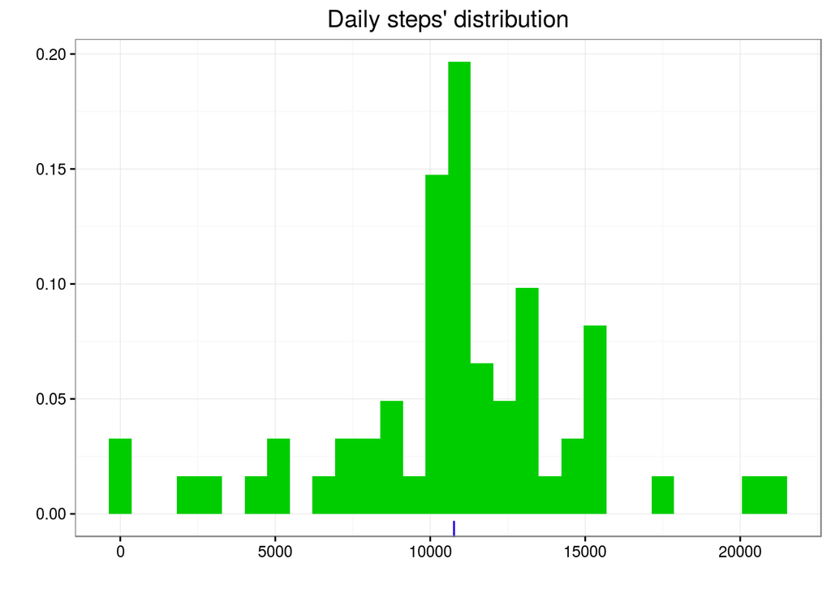

```r
means <- data  %>% group_by(interval) %>% summarise( med = mean(steps, na.rm = TRUE)) # the means of all intervals
index <- which( is.na(data$steps))  #the localitations of NA's in the dataset
data2 <- data
data2$steps[index] <- mapply(function(x){return( means$med[ which(means$interval == x ) ])   }, data$interval[index]) #replace NA's

a <- data2 %>% group_by(date) %>% summarise(steps=sum(steps, na.rm =TRUE))
m <- mean(a$steps, na.rm = TRUE)
med <- median(a$steps, na.rm = TRUE)
rugs <- data.frame(steps=c(m,med))
ggplot(a, aes(x = steps)) + geom_histogram(aes(y = ..count../sum(..count..)), fill='green3') + ggtitle("Daily steps' distribution") + ylab('')+ xlab('') +theme_bw() +geom_rug(data = rugs, colour = c('red', 'blue'))
```

## Differences in activity patterns between weekdays and weekends

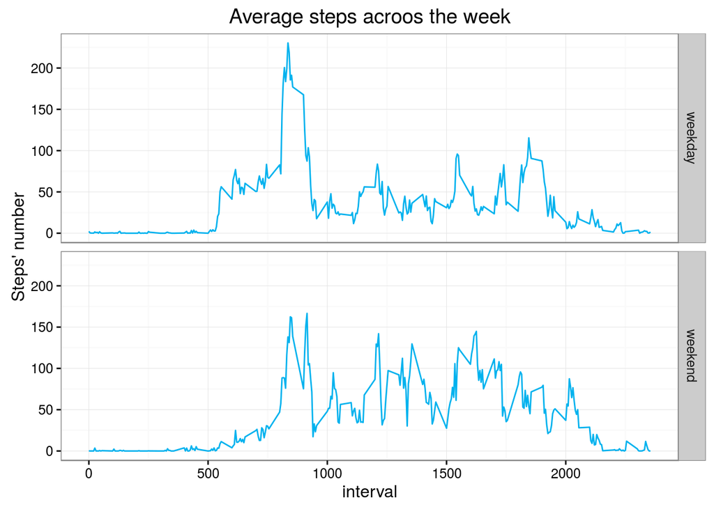

```r
data2$end <- weekdays(data2$date) %in% c('sábado','domingo')
data2$end <- factor(data2$end, labels = c("weekday", "weekend" ))
a <- data2 %>% group_by(interval,end) %>% summarise(steps=mean(steps, na.rm = TRUE))
ggplot(a, aes(x = interval, y = steps)) + geom_line(colour = 'deepskyblue2') +
    ylab("Steps' number") + theme_bw()  + ggtitle('Average steps acroos the week')+
    theme_bw() + facet_grid(end ~ .)
```